# RBF

**class*sklearn.gaussian_process.kernels.RBF(*length_scale=1.0*, *length_scale_bounds=(1e-05, 100000.0)*)[[source]](https://github.com/scikit-learn/scikit-learn/blob/99bf3d8e4/sklearn/gaussian_process/kernels.py#L1445)**

Radial basis function kernel (aka squared-exponential kernel).

The RBF kernel is a stationary kernel. It is also known as the “squared exponential” kernel. It is parameterized by a length scale parameter $l>0$, which can either be a scalar (isotropic variant of the kernel) or a vector with the same number of dimensions as the inputs X (anisotropic variant of the kernel). The kernel is given by:

$k(x_i, x_j) = \exp\left(- \frac{d(x_i, x_j)^2}{2l^2} \right)$

where $l$ is the length scale of the kernel and $d(\cdot,\cdot)$ is the Euclidean distance. For advice on how to set the length scale parameter, see e.g. [1].

This kernel is infinitely differentiable, which implies that GPs with this kernel as covariance function have mean square derivatives of all orders, and are thus very smooth. See [2], Chapter 4, Section 4.2, for further details of the RBF kernel.

Read more in the User Guide.

Added in version 0.18.

**Parameters:**

**length_scale**float or ndarray of shape (n_features,), default=1.0**

The length scale of the kernel. If a float, an isotropic kernel is used. If an array, an anisotropic kernel is used where each dimension of l defines the length-scale of the respective feature dimension.

**length_scale_bounds**pair of floats >= 0 or “fixed”, default=(1e-5, 1e5)**

The lower and upper bound on ‘length_scale’. If set to “fixed”, ‘length_scale’ cannot be changed during hyperparameter tuning.

#### References

[David Duvenaud (2014). “The Kernel Cookbook: Advice on Covariance functions”.](https://www.cs.toronto.edu/~duvenaud/cookbook/)

[Carl Edward Rasmussen, Christopher K. I. Williams (2006). “Gaussian Processes for Machine Learning”. The MIT Press.](http://www.gaussianprocess.org/gpml/)

#### Examples

```
>>> from sklearn.datasets import load_iris
>>> from sklearn.gaussian_process import GaussianProcessClassifier
>>> from sklearn.gaussian_process.kernels import RBF
>>> X, y = load_iris(return_X_y=True)
>>> kernel = 1.0 * RBF(1.0)
>>> gpc = GaussianProcessClassifier(kernel=kernel,
...         random_state=0).fit(X, y)
>>> gpc.score(X, y)
0.9866...
>>> gpc.predict_proba(X[:2,:])
array([[0.8354..., 0.03228..., 0.1322...],
       [0.7906..., 0.0652..., 0.1441...]])
```

**__call__(*X*, *Y=None*, *eval_gradient=False*)[[source]](https://github.com/scikit-learn/scikit-learn/blob/99bf3d8e4/sklearn/gaussian_process/kernels.py#L1527)**

Return the kernel k(X, Y) and optionally its gradient.

**Parameters:**

**X**ndarray of shape (n_samples_X, n_features)**

Left argument of the returned kernel k(X, Y)

**Y**ndarray of shape (n_samples_Y, n_features), default=None**

Right argument of the returned kernel k(X, Y). If None, k(X, X) if evaluated instead.

**eval_gradient**bool, default=False**

Determines whether the gradient with respect to the log of the kernel hyperparameter is computed. Only supported when Y is None.

**Returns:**

**K**ndarray of shape (n_samples_X, n_samples_Y)**

Kernel k(X, Y)

**K_gradient**ndarray of shape (n_samples_X, n_samples_X, n_dims), optional**

The gradient of the kernel k(X, X) with respect to the log of the hyperparameter of the kernel. Only returned when `eval_gradient` is True.

**property*bounds**

Returns the log-transformed bounds on the theta.

**Returns:**

**bounds**ndarray of shape (n_dims, 2)**

The log-transformed bounds on the kernel’s hyperparameters theta

**clone_with_theta(*theta*)[[source]](https://github.com/scikit-learn/scikit-learn/blob/99bf3d8e4/sklearn/gaussian_process/kernels.py#L260)**

Returns a clone of self with given hyperparameters theta.

**Parameters:**

**theta**ndarray of shape (n_dims,)**

The hyperparameters

**diag(*X*)[[source]](https://github.com/scikit-learn/scikit-learn/blob/99bf3d8e4/sklearn/gaussian_process/kernels.py#L470)**

Returns the diagonal of the kernel k(X, X).

The result of this method is identical to np.diag(self(X)); however, it can be evaluated more efficiently since only the diagonal is evaluated.

**Parameters:**

**X**ndarray of shape (n_samples_X, n_features)**

Left argument of the returned kernel k(X, Y)

**Returns:**

**K_diag**ndarray of shape (n_samples_X,)**

Diagonal of kernel k(X, X)

**get_params(*deep=True*)[[source]](https://github.com/scikit-learn/scikit-learn/blob/99bf3d8e4/sklearn/gaussian_process/kernels.py#L180)**

Get parameters of this kernel.

**Parameters:**

**deep**bool, default=True**

If True, will return the parameters for this estimator and contained subobjects that are estimators.

**Returns:**

**params**dict**

Parameter names mapped to their values.

**property*hyperparameters**

Returns a list of all hyperparameter specifications.

**is_stationary()[[source]](https://github.com/scikit-learn/scikit-learn/blob/99bf3d8e4/sklearn/gaussian_process/kernels.py#L496)**

Returns whether the kernel is stationary.

**property*n_dims**

Returns the number of non-fixed hyperparameters of the kernel.

**property*requires_vector_input**

Returns whether the kernel is defined on fixed-length feature vectors or generic objects. Defaults to True for backward compatibility.

**set_params(**params)[[source]](https://github.com/scikit-learn/scikit-learn/blob/99bf3d8e4/sklearn/gaussian_process/kernels.py#L220)**

Set the parameters of this kernel.

The method works on simple kernels as well as on nested kernels. The latter have parameters of the form `<component>__<parameter>` so that it’s possible to update each component of a nested object.

**Returns:**

**self**

**property*theta**

Returns the (flattened, log-transformed) non-fixed hyperparameters.

Note that theta are typically the log-transformed values of the kernel’s hyperparameters as this representation of the search space is more amenable for hyperparameter search, as hyperparameters like length-scales naturally live on a log-scale.

**Returns:**

**theta**ndarray of shape (n_dims,)**

The non-fixed, log-transformed hyperparameters of the kernel

## Gallery examples

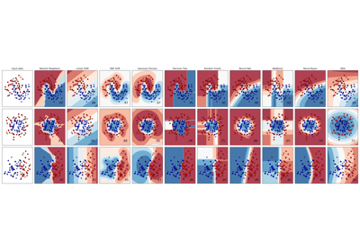

Classifier comparison

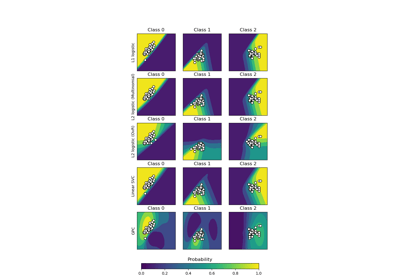

Plot classification probability

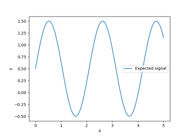

Ability of Gaussian process regression (GPR) to estimate data noise-level

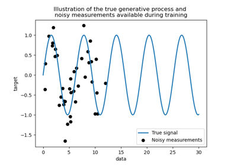

Comparison of kernel ridge and Gaussian process regression

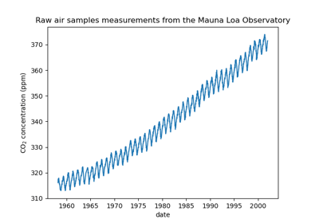

Forecasting of CO2 level on Mona Loa dataset using Gaussian process regression (GPR)

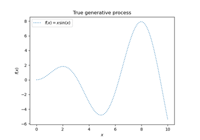

Gaussian Processes regression: basic introductory example

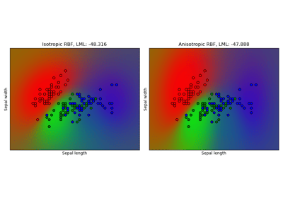

Gaussian process classification (GPC) on iris dataset

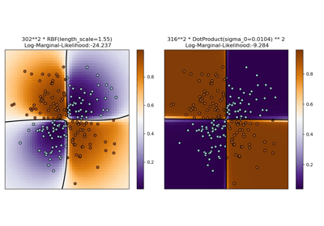

Illustration of Gaussian process classification (GPC) on the XOR dataset

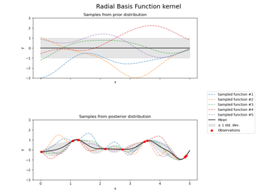

Illustration of prior and posterior Gaussian process for different kernels

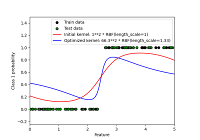

Probabilistic predictions with Gaussian process classification (GPC)

© 2007–2025 The scikit-learn developers  
Licensed under the 3-clause BSD License.  
https://scikit-learn.org/1.6/modules/generated/sklearn.gaussian_process.kernels.RBF.html